# project

```python
from RungeKutteM import RungeKutteMethod
from AdamsM import adams_method
import pandas as pd
import numpy as np
from matplotlib import pyplot as plt
from runge_rule import runge_rule
from CaushiM import eilerMethod
from runge_rule import runge_rule
```

```python
delta = 10
r = 1
b = 8/3
```

```python
def xfunc(t, x, y, z):
    return delta * (y - x)
def yfunc(t, x, y, z):
    return x * (r - z) - y
def zfunc(t, x, y, z):
    return x * y - b * z
```

Эта функция строит график решений для 3 численных методов

```python
def solving_with_graph(start_values: list, amount_of_points: int):
    k = RungeKutteMethod([xfunc, yfunc, zfunc], 0, 1, start_values, amount_of_points)
    a = np.linspace(0, 1, amount_of_points)
    my = []
    my1 = []
    my2 = []
    for i in range(len(k)):
        my.append(k[i][1])
        my1.append(k[i][0])
        my2.append(k[i][2])

    plt.plot(a, my, color = 'orange')
    plt.plot(a, my1, color = 'green')
    plt.plot(a, my2, color = 'purple')
    plt.scatter(a,my, color = "green")
    plt.scatter(a, my1, color = 'black')
    plt.show()
    plt.close()

    fig = plt.figure()
    ax = fig.add_subplot(projection='3d')

        # !!!
    ax.plot3D(my, my1, my2, 'gray')

    plt.show()

    k = eilerMethod([xfunc, yfunc, zfunc], 0, 1, start_values, amount_of_points)

    my = []
    my1 = []
    my2 = []
    for i in range(len(k)):
        my.append(k[i][1])
        my1.append(k[i][0])
        my2.append(k[i][2])

    plt.plot(a, my, color = 'orange')
    plt.plot(a, my1, color = 'green')
    plt.plot(a, my2, color = 'purple')
    plt.scatter(a,my, color = "green")
    plt.scatter(a, my1, color = 'black')
    plt.show()
    plt.close()



    k = adams_method([xfunc, yfunc, zfunc], 0, 1, start_values, amount_of_points)

    my = []
    my1 = []
    my2 = []
    for i in range(len(k)):
        my.append(k[i][1])
        my1.append(k[i][0])
        my2.append(k[i][2])

    plt.plot(a, my, color = 'orange')
    plt.plot(a, my1, color = 'green')
    plt.plot(a, my2, color = 'purple')
    plt.scatter(a,my, color = "green")
    plt.scatter(a, my1, color = 'black')
    plt.show()
    plt.close()
```

Тут видно, что при начальных значениях 0,0,0 решение системы будет тождестевнный 0. Потому что ни 1 из методов не может пройти это значение в силу того как они написаны. Поэтому далее будем использовать значения, приближенные к 0

[figure not shown]

```python
solving_with_graph([0, 0, 0], 1280)
```

[output not shown]

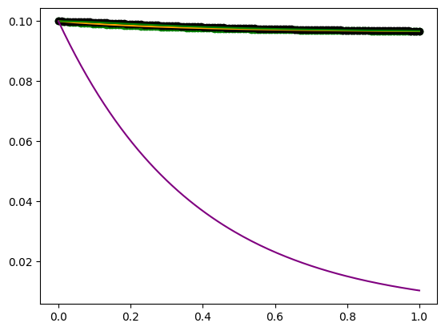

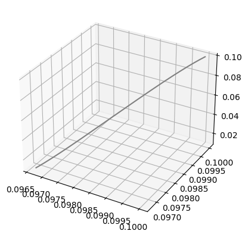

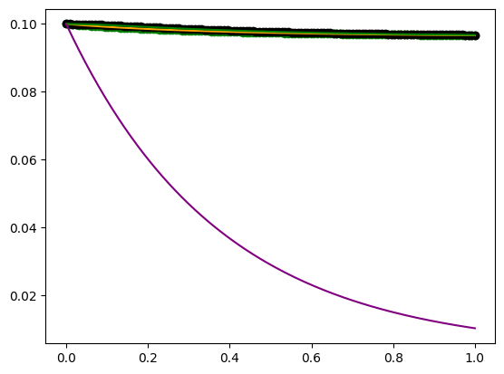

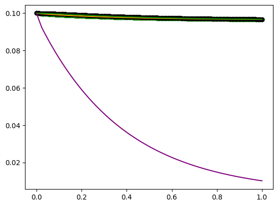

```python
solving_with_graph([0.1, 0.1, 0.1], 128)
```

Также, я решил 1 из начальных значений поменять на 10, чтобы графики не сливались в процессе. И исследовать поведение параметров для этих значений

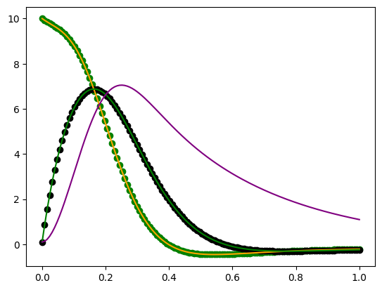

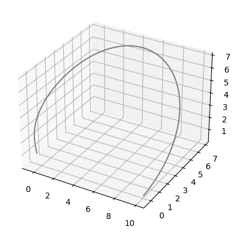

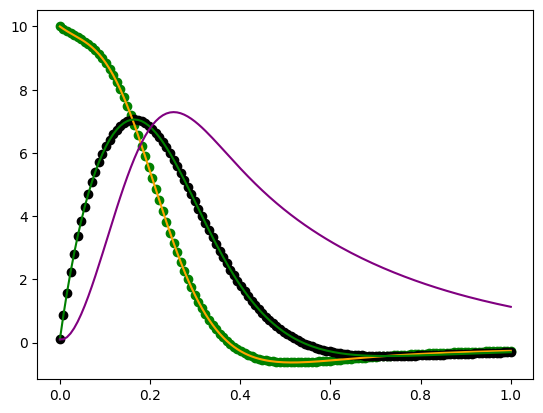

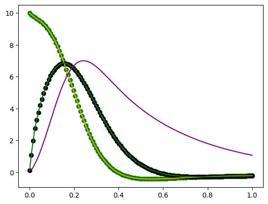

```python
solving_with_graph([0.1, 10, 0.1], 128)
```

Теперь меняем значения параметров, оставляя начальные значения такими же. Как указано в учебнике, будем менять только r

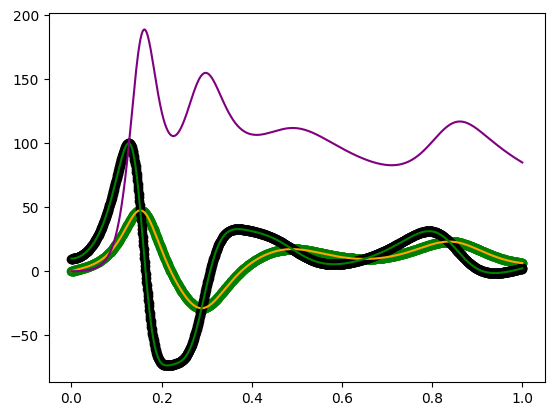

```python
r = 100
k = RungeKutteMethod([xfunc, yfunc, zfunc], 0, 1, [0.1, 10, 0.1], 1280)
a = np.linspace(0, 1, 1280)
my = np.array([k[i][0] for i in range(len(k))])
my1 = np.array([k[i][1] for i in range(len(k))])
my2 = np.array([k[i][2] for i in range(len(k))])

plt.plot(a, my, color = 'orange')
plt.plot(a, my1, color = 'green')
plt.plot(a, my2, color = 'purple')
plt.scatter(a,my, color = "green")
plt.scatter(a, my1, color = 'black')
plt.show()
plt.close()
```

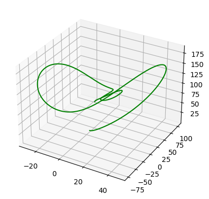

```python
fig = plt.figure()
ax = fig.add_subplot(projection='3d')

    # !!!
ax.plot3D(my, my1, my2, 'green')

plt.show()
```

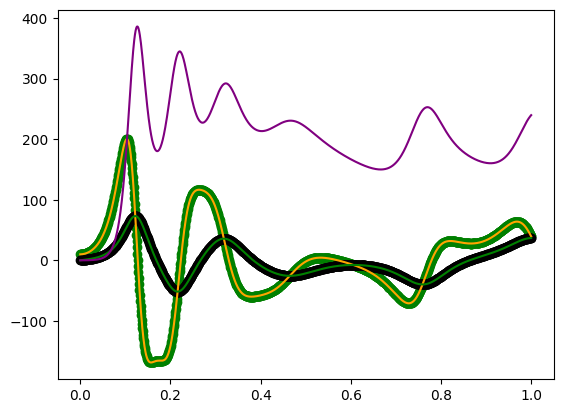

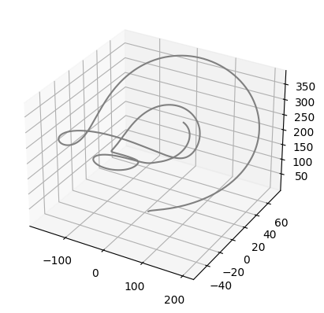

```python
r = 200
k = RungeKutteMethod([xfunc, yfunc, zfunc], 0, 1, [0.1, 10, 0.1], 1280)
a = np.linspace(0, 1, 1280)
my = []
my1 = []
my2 = []
for i in range(len(k)):
    my.append(k[i][1])
    my1.append(k[i][0])
    my2.append(k[i][2])

plt.plot(a, my, color = 'orange')
plt.plot(a, my1, color = 'green')
plt.plot(a, my2, color = 'purple')
plt.scatter(a,my, color = "green")
plt.scatter(a, my1, color = 'black')
plt.show()
plt.close()


fig = plt.figure()
ax = fig.add_subplot(projection='3d')

    # !!!
ax.plot3D(my, my1, my2, 'gray')

plt.show()
```

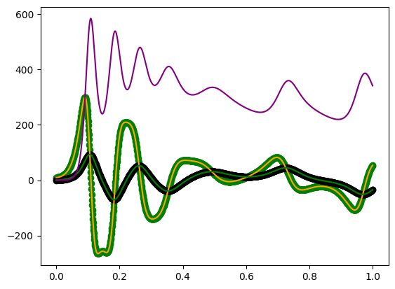

```python
r = 300
k = RungeKutteMethod([xfunc, yfunc, zfunc], 0, 1, [0.1, 10, 0.1], 1280)
a = np.linspace(0, 1, 1280)
my = []
my1 = []
my2 = []
for i in range(len(k)):
    my.append(k[i][1])
    my1.append(k[i][0])
    my2.append(k[i][2])

plt.plot(a, my, color = 'orange')
plt.plot(a, my1, color = 'green')
plt.plot(a, my2, color = 'purple')
plt.scatter(a,my, color = "green")
plt.scatter(a, my1, color = 'black')
plt.show()
plt.close()
```

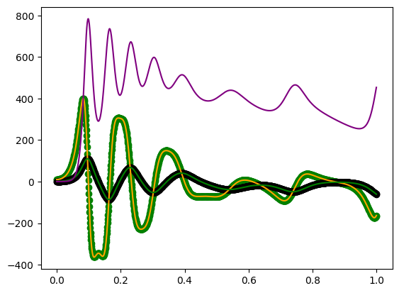

```python
r = 400
k = RungeKutteMethod([xfunc, yfunc, zfunc], 0, 1, [0.1, 10, 0.1], 1280)
a = np.linspace(0, 1, 1280)
my = []
my1 = []
my2 = []
for i in range(len(k)):
    my.append(k[i][1])
    my1.append(k[i][0])
    my2.append(k[i][2])

plt.plot(a, my, color = 'orange')
plt.plot(a, my1, color = 'green')
plt.plot(a, my2, color = 'purple')
plt.scatter(a,my, color = "green")
plt.scatter(a, my1, color = 'black')
plt.show()
plt.close()
```

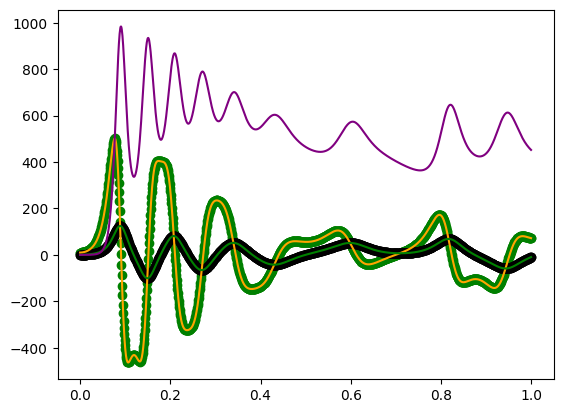

```python
r = 500
k = RungeKutteMethod([xfunc, yfunc, zfunc], 0, 1, [0.1, 10, 0.1], 1280)
a = np.linspace(0, 1, 1280)
my = []
my1 = []
my2 = []
for i in range(len(k)):
    my.append(k[i][1])
    my1.append(k[i][0])
    my2.append(k[i][2])

plt.plot(a, my, color = 'orange')
plt.plot(a, my1, color = 'green')
plt.plot(a, my2, color = 'purple')
plt.scatter(a,my, color = "green")
plt.scatter(a, my1, color = 'black')
plt.show()
plt.close()
```

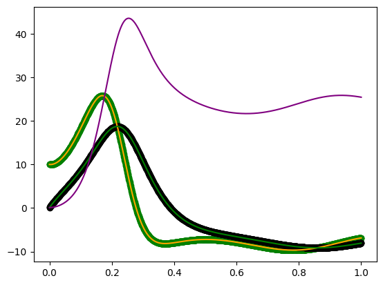

```python
r = 24.74
k = RungeKutteMethod([xfunc, yfunc, zfunc], 0, 1, [0.1, 10, 0.1], 1280)
a = np.linspace(0, 1, 1280)
my = []
my1 = []
my2 = []
for i in range(len(k)):
    my.append(k[i][1])
    my1.append(k[i][0])
    my2.append(k[i][2])

plt.plot(a, my, color = 'orange')
plt.plot(a, my1, color = 'green')
plt.plot(a, my2, color = 'purple')
plt.scatter(a,my, color = "green")
plt.scatter(a, my1, color = 'black')
plt.show()
plt.close()
```

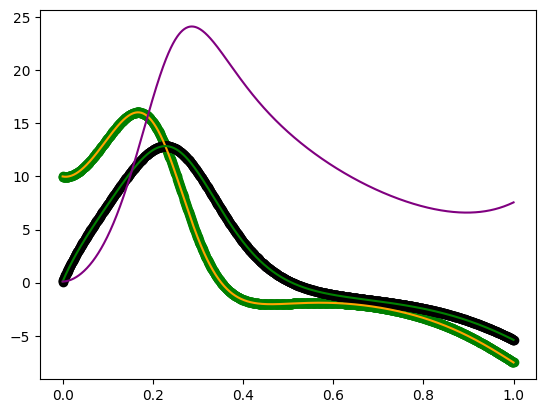

```python
r = 13.926
k = RungeKutteMethod([xfunc, yfunc, zfunc], 0, 1, [0.1, 10, 0.1], 1280)
a = np.linspace(0, 1, 1280)
my = []
my1 = []
my2 = []
for i in range(len(k)):
    my.append(k[i][1])
    my1.append(k[i][0])
    my2.append(k[i][2])

plt.plot(a, my, color = 'orange')
plt.plot(a, my1, color = 'green')
plt.plot(a, my2, color = 'purple')
plt.scatter(a,my, color = "green")
plt.scatter(a, my1, color = 'black')
plt.show()
plt.close()
```

Будем рассматривать систему на временном промежутке от 0 до 100. Параметры, как и стартовое значение будут варироваться. Их видно в коде, иногда я их буду указывать в markdownах

Рассмотрим систему, где 0 < r < 1. С начальными значениями

```python
func = [xfunc, yfunc, zfunc]
start_values = [2, 3, -4]
```

```python
eps = 1e-9
ru = runge_rule(RungeKutteMethod, func, 0, 100, start_values, eps)
ei = runge_rule(eilerMethod, func, 0, 100, start_values, eps)
ad = runge_rule(adams_method, func, 0, 100, start_values, eps)
print(pd.DataFrame(ru))
```

```
[[-5.871058961834165, -5.87105896183416, 12.926000000000004, 10]]
3
[-5.871058961834181, -5.871058961834191, 12.92599999999999]
[[-5.871059034140803, -5.871059037516005, 12.926000060098596, 10]]
3
[-5.871058961835298, -5.871058961835944, 12.925999999999908]
[[-5.871058961834178, -5.8710589618341835, 12.926000000000007, 10]]
3
[-5.871058961834183, -5.871058961834193, 12.925999999999997]
          0         1       2             3
0 -5.871059 -5.871059  12.926  1.000000e+01
1 -5.871059 -5.871059  12.926  3.019807e-14
```

```
                   0             1             2
0       2.000000e+00  3.000000e+00 -4.000000e+00
1       2.007800e+00  3.004063e+00 -3.986980e+00
2       2.015572e+00  3.008128e+00 -3.973963e+00
3       2.023314e+00  3.012193e+00 -3.960948e+00
4       2.031028e+00  3.016259e+00 -3.947935e+00
...              ...           ...           ...
127995  2.187379e-39  1.992653e-39  4.917765e-78
127996  2.185858e-39  1.991267e-39  4.910929e-78
127997  2.184338e-39  1.989883e-39  4.904102e-78
127998  2.182820e-39  1.988499e-39  4.897285e-78
127999  2.181302e-39  1.987116e-39  4.890477e-78

[128000 rows x 3 columns]
```

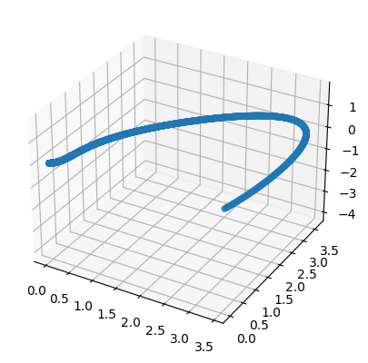

```python
r = 1/10
k = RungeKutteMethod(func, 0, 100, start_values, 128000)
print(pd.DataFrame(k))
xcoord = [k[i][0] for i in range(len(k))]
ycoord = [k[i][1] for i in range(len(k))]
zcoord = [k[i][2] for i in range(len(k))]
fig = plt.figure()
ax = fig.add_subplot(projection='3d')

    # !!!
ax.plot3D(xcoord, ycoord, zcoord, 'gray')
ax.scatter3D(xcoord, ycoord, zcoord)
plt.show()
```

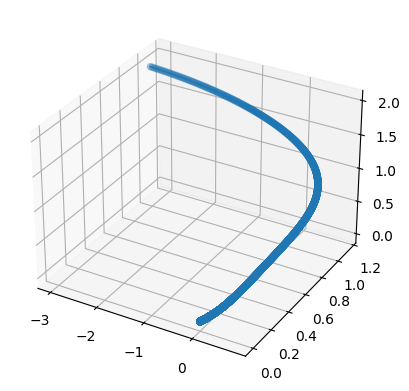

```python
start_values = [-3, 1, 2]
k = RungeKutteMethod(func, 0, 100, start_values, 128000)

xcoord = [k[i][0] for i in range(len(k))]
ycoord = [k[i][1] for i in range(len(k))]
zcoord = [k[i][2] for i in range(len(k))]
fig = plt.figure()
ax = fig.add_subplot(projection='3d')

    # !!!
ax.plot3D(xcoord, ycoord, zcoord, 'gray')
ax.scatter3D(xcoord, ycoord, zcoord)
plt.show()
```

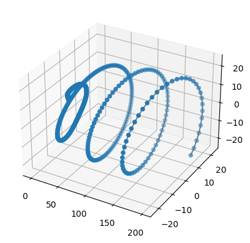

```python
start_values = [200, 10, -20]
k = RungeKutteMethod(func, 0, 100, start_values, 128000)

xcoord = [k[i][0] for i in range(len(k))]
ycoord = [k[i][1] for i in range(len(k))]
zcoord = [k[i][2] for i in range(len(k))]
fig = plt.figure()
ax = fig.add_subplot(projection='3d')

    # !!!
ax.plot3D(xcoord, ycoord, zcoord, 'gray')
ax.scatter3D(xcoord, ycoord, zcoord)
plt.show()
```

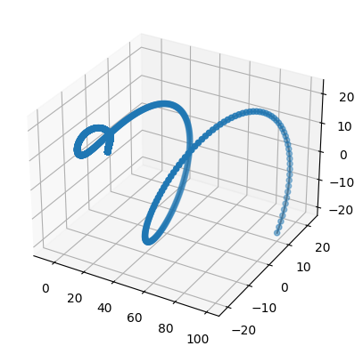

```python
start_values = [100, 10, -20]
k = RungeKutteMethod(func, 0, 100, start_values, 128000)

xcoord = [k[i][0] for i in range(len(k))]
ycoord = [k[i][1] for i in range(len(k))]
zcoord = [k[i][2] for i in range(len(k))]
fig = plt.figure()
ax = fig.add_subplot(projection='3d')

    # !!!
ax.plot3D(xcoord, ycoord, zcoord, 'gray')
ax.scatter3D(xcoord, ycoord, zcoord)
plt.show()
```

возьмём r = 1. И внесем небольшой шум в данные. Из предыдущих наблюдений видно, что когда начальные значения достаточно маленькие, фигура получается простой. Поэтому и начальные значения возьмем близкие к единице по модулю

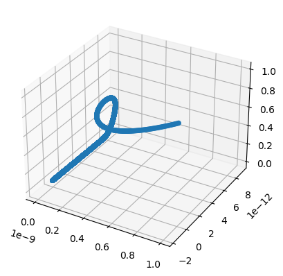

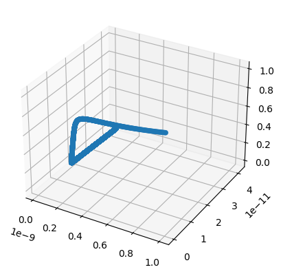

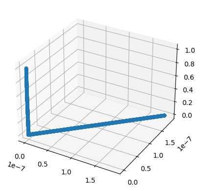

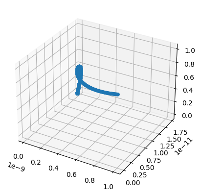

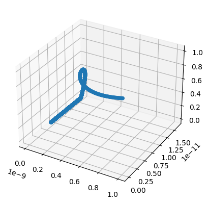

```python
r = 9/10
start_values = [1.e-9, 0, 1]
k = RungeKutteMethod(func, 0, 100, start_values, 128000)

xcoord = [k[i][0] for i in range(len(k))]
ycoord = [k[i][1] for i in range(len(k))]
zcoord = [k[i][2] for i in range(len(k))]
fig = plt.figure()
ax = fig.add_subplot(projection='3d')

    # !!!
ax.plot3D(xcoord, ycoord, zcoord, 'gray')
ax.scatter3D(xcoord, ycoord, zcoord)
plt.show()

r = 1.01
k = RungeKutteMethod(func, 0, 100, start_values, 128000)

xcoord = [k[i][0] for i in range(len(k))]
ycoord = [k[i][1] for i in range(len(k))]
zcoord = [k[i][2] for i in range(len(k))]
fig = plt.figure()
ax = fig.add_subplot(projection='3d')

    # !!!
ax.plot3D(xcoord, ycoord, zcoord, 'gray')
ax.scatter3D(xcoord, ycoord, zcoord)
plt.show()


r = 1.1
k = RungeKutteMethod(func, 0, 100, start_values, 128000)

xcoord = [k[i][0] for i in range(len(k))]
ycoord = [k[i][1] for i in range(len(k))]
zcoord = [k[i][2] for i in range(len(k))]
fig = plt.figure()
ax = fig.add_subplot(projection='3d')

    # !!!
ax.plot3D(xcoord, ycoord, zcoord, 'gray')
ax.scatter3D(xcoord, ycoord, zcoord)
plt.show()

r = 1
k = RungeKutteMethod(func, 0, 100, start_values, 128000)

xcoord = [k[i][0] for i in range(len(k))]
ycoord = [k[i][1] for i in range(len(k))]
zcoord = [k[i][2] for i in range(len(k))]
fig = plt.figure()
ax = fig.add_subplot(projection='3d')

    # !!!
ax.plot3D(xcoord, ycoord, zcoord, 'gray')
ax.scatter3D(xcoord, ycoord, zcoord)
plt.show()

r = 0.99
k = RungeKutteMethod(func, 0, 100, start_values, 128000)

xcoord = [k[i][0] for i in range(len(k))]
ycoord = [k[i][1] for i in range(len(k))]
zcoord = [k[i][2] for i in range(len(k))]
fig = plt.figure()
ax = fig.add_subplot(projection='3d')

    # !!!
ax.plot3D(xcoord, ycoord, zcoord, 'gray')
ax.scatter3D(xcoord, ycoord, zcoord)
plt.show()
```

Видно, что r = 1 - точка бифуркации. При небольших изменениях этого параметра, график принимает разный вид. То есть, решения системы уравнений сильно отличаются.